# Task 15 : Take Me Out to the Ballgame

TomHollinberger

10/15/2020

THIS RSCRIPT USES ROXYGEN CHARACTERS.  
YOU CAN PRESS ctrl+shift+K AND GO STRAIGHT TO A HTML.  
SKIPS THE HANDWORK OF CREATING A RMD, AFTER THE ORIGINAL WORK IS NONE IN A RSCRIPT. E:/000 DTS 350 Data Visualization/DTS350-hollinbergert/DTS350TemplateMaster/Week_08/Class_Task_15/

```r
library(tidyverse)
library(readr)
library(haven)
library(readxl)
library(downloader)
library(dplyr)
library(foreign)  #for read.dbf
```

install Lahman and blscrapeR

```r
library(Lahman)
library(blscrapeR)
```

[ ] Take notes on your reading of the specified ‘R for Data Science’ chapter in the README.md or in a ‘.R’ script in the class task folder. [ ] Install the library(Lahman) and examine the available data sets available. [ ] Find the 4-5 different data sets that you will need to show full college and player names as well as their annual earnings. You might want to draw a diagram to show how the data sets are related.

```r
str(Schools)
```

```
## 'data.frame':    1207 obs. of  5 variables:
##  $ schoolID : chr  "abilchrist" "adelphi" "adrianmi" "akron" ...
##  $ name_full: chr  "Abilene Christian University" "Adelphi University" "Adrian College" "University of Akron" ...
##  $ city     : chr  "Abilene" "Garden City" "Adrian" "Akron" ...
##  $ state    : chr  "TX" "NY" "MI" "OH" ...
##  $ country  : chr  "USA" "USA" "USA" "USA" ...
```

```r
str(CollegePlaying)
```

```
## 'data.frame':    17350 obs. of  3 variables:
##  $ playerID: chr  "aardsda01" "aardsda01" "aardsda01" "abadan01" ...
##  $ schoolID: chr  "pennst" "rice" "rice" "gamiddl" ...
##  $ yearID  : int  2001 2002 2003 1992 1993 1889 1890 1891 1892 1991 ...
```

```r
str(People)
```

```
## 'data.frame':    19878 obs. of  26 variables:
##  $ playerID    : chr  "aardsda01" "aaronha01" "aaronto01" "aasedo01" ...
##  $ birthYear   : int  1981 1934 1939 1954 1972 1985 1850 1877 1869 1866 ...
##  $ birthMonth  : int  12 2 8 9 8 12 11 4 11 10 ...
##  $ birthDay    : int  27 5 5 8 25 17 4 15 11 14 ...
##  $ birthCountry: chr  "USA" "USA" "USA" "USA" ...
##  $ birthState  : chr  "CO" "AL" "AL" "CA" ...
##  $ birthCity   : chr  "Denver" "Mobile" "Mobile" "Orange" ...
##  $ deathYear   : int  NA NA 1984 NA NA NA 1905 1957 1962 1926 ...
##  $ deathMonth  : int  NA NA 8 NA NA NA 5 1 6 4 ...
##  $ deathDay    : int  NA NA 16 NA NA NA 17 6 11 27 ...
##  $ deathCountry: chr  NA NA "USA" NA ...
##  $ deathState  : chr  NA NA "GA" NA ...
##  $ deathCity   : chr  NA NA "Atlanta" NA ...
##  $ nameFirst   : chr  "David" "Hank" "Tommie" "Don" ...
##  $ nameLast    : chr  "Aardsma" "Aaron" "Aaron" "Aase" ...
##  $ nameGiven   : chr  "David Allan" "Henry Louis" "Tommie Lee" "Donald William" ...
##  $ weight      : int  215 180 190 190 184 220 192 170 175 169 ...
##  $ height      : int  75 72 75 75 73 73 72 71 71 68 ...
##  $ bats        : Factor w/ 3 levels "B","L","R": 3 3 3 3 2 2 3 3 3 2 ...
##  $ throws      : Factor w/ 3 levels "L","R","S": 2 2 2 2 1 1 2 2 2 1 ...
##  $ debut       : chr  "2004-04-06" "1954-04-13" "1962-04-10" "1977-07-26" ...
##  $ finalGame   : chr  "2015-08-23" "1976-10-03" "1971-09-26" "1990-10-03" ...
##  $ retroID     : chr  "aardd001" "aaroh101" "aarot101" "aased001" ...
##  $ bbrefID     : chr  "aardsda01" "aaronha01" "aaronto01" "aasedo01" ...
##  $ deathDate   : Date, format: NA NA ...
##  $ birthDate   : Date, format: "1981-12-27" "1934-02-05" ...
```

```r
str(Salaries)
```

```
## 'data.frame':    26428 obs. of  5 variables:
##  $ yearID  : int  1985 1985 1985 1985 1985 1985 1985 1985 1985 1985 ...
##  $ teamID  : Factor w/ 35 levels "ANA","ARI","ATL",..: 3 3 3 3 3 3 3 3 3 3 ...
##  $ lgID    : Factor w/ 2 levels "AL","NL": 2 2 2 2 2 2 2 2 2 2 ...
##  $ playerID: chr  "barkele01" "bedrost01" "benedbr01" "campri01" ...
##  $ salary  : int  870000 550000 545000 633333 625000 800000 150000 483333 772000 250000 ...
```

```r
str(Teams)
```

```
## 'data.frame':    2925 obs. of  48 variables:
##  $ yearID        : int  1871 1871 1871 1871 1871 1871 1871 1871 1871 1872 ...
##  $ lgID          : Factor w/ 7 levels "AA","AL","FL",..: 4 4 4 4 4 4 4 4 4 4 ...
##  $ teamID        : Factor w/ 149 levels "ALT","ANA","ARI",..: 24 31 39 56 90 97 111 136 142 8 ...
##  $ franchID      : Factor w/ 120 levels "ALT","ANA","ARI",..: 13 36 25 56 70 85 91 109 77 9 ...
##  $ divID         : chr  NA NA NA NA ...
##  $ Rank          : int  3 2 8 7 5 1 9 6 4 2 ...
##  $ G             : int  31 28 29 19 33 28 25 29 32 58 ...
##  $ Ghome         : int  NA NA NA NA NA NA NA NA NA NA ...
##  $ W             : int  20 19 10 7 16 21 4 13 15 35 ...
##  $ L             : int  10 9 19 12 17 7 21 15 15 19 ...
##  $ DivWin        : chr  NA NA NA NA ...
##  $ WCWin         : chr  NA NA NA NA ...
##  $ LgWin         : chr  "N" "N" "N" "N" ...
##  $ WSWin         : chr  NA NA NA NA ...
```

[output cut: 34 more lines]

Find Primary Keys for each

```r
Schools %>%
  count(schoolID) %>%
  filter(n > 1)
```

```
## [1] schoolID n
## <0 rows> (or 0-length row.names)
```

Result: <0 rows> (or 0-length row.names) which means it’s the primary key

```r
CollegePlaying %>%
  count(playerID, schoolID, yearID) %>%
  filter(n > 1)
```

```
## [1] playerID schoolID yearID   n
## <0 rows> (or 0-length row.names)
```

Result: <0 rows> (or 0-length row.names) which means it’s the COMPOSITE primary keylibrary(Lahman)

```r
People %>%
count(playerID) %>%
  filter(n > 1)
```

```
## [1] playerID n
## <0 rows> (or 0-length row.names)
```

Result: <0 rows> (or 0-length row.names) which means it’s the primary key

```r
Salaries %>%
count(playerID, yearID, teamID) %>%
  filter(n > 1)
```

```
## [1] playerID yearID   teamID   n
## <0 rows> (or 0-length row.names)
```

Result: <0 rows> (or 0-length row.names) which means it’s the COMPOSITE primary key

```r
Teams %>%
count(yearID, teamID) %>%
  filter(n > 1)
```

```
## [1] yearID teamID n
## <0 rows> (or 0-length row.names)
```

Result: <0 rows> (or 0-length row.names) which means it’s the COMPOSITE primary key

Create a table for Inflation adjustment factors [ ] Install the library(blscrapeR) and use the inflation_adjust(2017) function to get all earnings in 2017 dollars.

```r
library(blscrapeR)

bls <- inflation_adjust(2017)
```

View(bls)

```r
bls <- mutate(bls,salyr = year)
bls <- mutate(bls,divisortoget2017 = adj_value)
bls   #salyr will be the key to link to Salaries
```

```
## # A tibble: 74 x 7
##    year  avg_cpi adj_value base_year pct_increase salyr divisortoget2017
##    <chr>   <dbl>     <dbl> <chr>            <dbl> <chr>            <dbl>
##  1 1947     22.3      0.09 2017             -90.9 1947              0.09
##  2 1948     24.0      0.1  2017             -90.2 1948              0.1
##  3 1949     23.8      0.1  2017             -90.3 1949              0.1
##  4 1950     24.1      0.1  2017             -90.2 1950              0.1
##  5 1951     26.0      0.11 2017             -89.4 1951              0.11
##  6 1952     26.6      0.11 2017             -89.2 1952              0.11
##  7 1953     26.8      0.11 2017             -89.1 1953              0.11
##  8 1954     26.9      0.11 2017             -89.0 1954              0.11
##  9 1955     26.8      0.11 2017             -89.1 1955              0.11
## 10 1956     27.2      0.11 2017             -88.9 1956              0.11
## # ... with 64 more rows
```

will eventually take then-year-sal and divide by divisortoget2017 from bls to get equivalent 2017-dollars.

Cut and Paste these into excel database schematic. Column-to-text to extract the Vsar name. Create the database diagram with the dataframe that you need to create to answer the question in the middle. See 15Task DB Schematic.xls

Remove all variables except for Primary keys and desired-answer variables

```r
tms <- select(Teams, teamID, yearID, name)
tms
```

```
##      teamID yearID                              name
## 1       BS1   1871              Boston Red Stockings
## 2       CH1   1871           Chicago White Stockings
## 3       CL1   1871            Cleveland Forest Citys
## 4       FW1   1871              Fort Wayne Kekiongas
## 5       NY2   1871                  New York Mutuals
## 6       PH1   1871            Philadelphia Athletics
## 7       RC1   1871             Rockford Forest Citys
## 8       TRO   1871                    Troy Haymakers
## 9       WS3   1871               Washington Olympics
## 10      BL1   1872                Baltimore Canaries
## 11      BR1   1872                 Brooklyn Eckfords
## 12      BR2   1872                Brooklyn Atlantics
## 13      BS1   1872              Boston Red Stockings
## 14      CL1   1872            Cleveland Forest Citys
```

[output cut: 2911 more lines]

```r
schl <- select(Schools, schoolID, name_full, state)
schl
```

```
##           schoolID
## 1       abilchrist
## 2          adelphi
## 3         adrianmi
## 4            akron
## 5          alabama
## 6        alabamaam
## 7        alabamast
## 8         albanyst
## 9       albertsnid
## 10         albevil
## 11        albionmi
## 12      albrightpa
## 13         alcalho
## 14         alchatt
```

[output cut: 3609 more lines]

```r
cpg <- CollegePlaying
cpg
```

```
##        playerID      schoolID yearID
## 1     aardsda01        pennst   2001
## 2     aardsda01          rice   2002
## 3     aardsda01          rice   2003
## 4      abadan01       gamiddl   1992
## 5      abadan01       gamiddl   1993
## 6     abbeybe01       vermont   1889
## 7     abbeybe01       vermont   1890
## 8     abbeybe01       vermont   1891
## 9     abbeybe01       vermont   1892
## 10    abbotje01      kentucky   1991
## 11    abbotje01      kentucky   1992
## 12    abbotje01      kentucky   1994
## 13    abbotji01      michigan   1986
## 14    abbotji01      michigan   1987
```

[output cut: 17336 more lines]

```r
sals <- select(Salaries, yearID, teamID, playerID, salary)
sals
```

```
##       yearID teamID  playerID   salary
## 1       1985    ATL barkele01   870000
## 2       1985    ATL bedrost01   550000
## 3       1985    ATL benedbr01   545000
## 4       1985    ATL  campri01   633333
## 5       1985    ATL ceronri01   625000
## 6       1985    ATL chambch01   800000
## 7       1985    ATL dedmoje01   150000
## 8       1985    ATL forstte01   483333
## 9       1985    ATL garbege01   772000
## 10      1985    ATL harpete01   250000
## 11      1985    ATL hornebo01  1500000
## 12      1985    ATL hubbagl01   455000
## 13      1985    ATL mahleri01   407500
## 14      1985    ATL mcmurcr01   275000
```

[output cut: 24986 more lines]

```r
ppl <- select(People, playerID, nameFirst, nameLast)
ppl
```

```
##        playerID    nameFirst       nameLast
## 1     aardsda01        David        Aardsma
## 2     aaronha01         Hank          Aaron
## 3     aaronto01       Tommie          Aaron
## 4      aasedo01          Don           Aase
## 5      abadan01         Andy           Abad
## 6      abadfe01     Fernando           Abad
## 7     abadijo01         John         Abadie
## 8     abbated01           Ed    Abbaticchio
## 9     abbeybe01         Bert          Abbey
## 10    abbeych01      Charlie          Abbey
## 11    abbotda01          Dan         Abbott
## 12    abbotfr01         Fred         Abbott
## 13    abbotgl01        Glenn         Abbott
## 14    abbotje01         Jeff         Abbott
```

[output cut: 19864 more lines]

```r
bls
```

```
## # A tibble: 74 x 7
##    year  avg_cpi adj_value base_year pct_increase salyr divisortoget2017
##    <chr>   <dbl>     <dbl> <chr>            <dbl> <chr>            <dbl>
##  1 1947     22.3      0.09 2017             -90.9 1947              0.09
##  2 1948     24.0      0.1  2017             -90.2 1948              0.1
##  3 1949     23.8      0.1  2017             -90.3 1949              0.1
##  4 1950     24.1      0.1  2017             -90.2 1950              0.1
##  5 1951     26.0      0.11 2017             -89.4 1951              0.11
##  6 1952     26.6      0.11 2017             -89.2 1952              0.11
##  7 1953     26.8      0.11 2017             -89.1 1953              0.11
##  8 1954     26.9      0.11 2017             -89.0 1954              0.11
##  9 1955     26.8      0.11 2017             -89.1 1955              0.11
## 10 1956     27.2      0.11 2017             -88.9 1956              0.11
## # ... with 64 more rows
```

```r
bls <- select(bls, salyr,divisortoget2017)
bls
```

```
## # A tibble: 74 x 2
##    salyr divisortoget2017
##    <chr>            <dbl>
##  1 1947              0.09
##  2 1948              0.1
##  3 1949              0.1
##  4 1950              0.1
##  5 1951              0.11
##  6 1952              0.11
##  7 1953              0.11
##  8 1954              0.11
##  9 1955              0.11
## 10 1956              0.11
## # ... with 64 more rows
```

```r
bls$salyr <- as.numeric(bls$salyr)  #needs to be similare var type as other instances of salyr (num)
str(bls)
```

```
## tibble [74 x 2] (S3: tbl_df/tbl/data.frame)
##  $ salyr           : num [1:74] 1947 1948 1949 1950 1951 ...
##  $ divisortoget2017: num [1:74] 0.09 0.1 0.1 0.1 0.11 0.11 0.11 0.11 0.11 0.11 ...
```

Join into a dataframe needed to answer the question

Add the full team name to our salary data set

```r
saltm <- sals %>%
  left_join(tms)
head(saltm)
```

```
##   yearID teamID  playerID salary           name
## 1   1985    ATL barkele01 870000 Atlanta Braves
## 2   1985    ATL bedrost01 550000 Atlanta Braves
## 3   1985    ATL benedbr01 545000 Atlanta Braves
## 4   1985    ATL  campri01 633333 Atlanta Braves
## 5   1985    ATL ceronri01 625000 Atlanta Braves
## 6   1985    ATL chambch01 800000 Atlanta Braves
```

```r
saltm <- mutate(saltm,salyr = yearID)  #chg yearID to salyr to deconflict with colyr
head(saltm)
```

```
##   yearID teamID  playerID salary           name salyr
## 1   1985    ATL barkele01 870000 Atlanta Braves  1985
## 2   1985    ATL bedrost01 550000 Atlanta Braves  1985
## 3   1985    ATL benedbr01 545000 Atlanta Braves  1985
## 4   1985    ATL  campri01 633333 Atlanta Braves  1985
## 5   1985    ATL ceronri01 625000 Atlanta Braves  1985
## 6   1985    ATL chambch01 800000 Atlanta Braves  1985
```

Add divisortoget2017 to salary data set

```r
saltminfl <- saltm %>%
  left_join(bls)
head(saltminfl)
```

```
##   yearID teamID  playerID salary           name salyr divisortoget2017
## 1   1985    ATL barkele01 870000 Atlanta Braves  1985             0.44
## 2   1985    ATL bedrost01 550000 Atlanta Braves  1985             0.44
## 3   1985    ATL benedbr01 545000 Atlanta Braves  1985             0.44
## 4   1985    ATL  campri01 633333 Atlanta Braves  1985             0.44
## 5   1985    ATL ceronri01 625000 Atlanta Braves  1985             0.44
## 6   1985    ATL chambch01 800000 Atlanta Braves  1985             0.44
```

```r
saltminfl <- mutate(saltminfl, sal2017 = salary/divisortoget2017)  #apply the divisor to create equivalent 2017 salary
head(saltminfl)
```

```
##   yearID teamID  playerID salary           name salyr divisortoget2017 sal2017
## 1   1985    ATL barkele01 870000 Atlanta Braves  1985             0.44 1977273
## 2   1985    ATL bedrost01 550000 Atlanta Braves  1985             0.44 1250000
## 3   1985    ATL benedbr01 545000 Atlanta Braves  1985             0.44 1238636
## 4   1985    ATL  campri01 633333 Atlanta Braves  1985             0.44 1439393
## 5   1985    ATL ceronri01 625000 Atlanta Braves  1985             0.44 1420455
## 6   1985    ATL chambch01 800000 Atlanta Braves  1985             0.44 1818182
```

Add the full school name to our college playing

```r
cpgschl <- cpg %>%
  left_join(schl)
head(cpgschl)
```

```
##    playerID schoolID yearID                     name_full state
## 1 aardsda01   pennst   2001 Pennsylvania State University    PA
## 2 aardsda01     rice   2002               Rice University    TX
## 3 aardsda01     rice   2003               Rice University    TX
## 4  abadan01  gamiddl   1992        Middle Georgia College    GA
## 5  abadan01  gamiddl   1993        Middle Georgia College    GA
## 6 abbeybe01  vermont   1889         University of Vermont    VT
```

```r
cpgschl <- mutate(cpgschl,colyr = yearID)  #chg yearID to colyr to deconflict with salyr
head(cpgschl)
```

```
##    playerID schoolID yearID                     name_full state colyr
## 1 aardsda01   pennst   2001 Pennsylvania State University    PA  2001
## 2 aardsda01     rice   2002               Rice University    TX  2002
## 3 aardsda01     rice   2003               Rice University    TX  2003
## 4  abadan01  gamiddl   1992        Middle Georgia College    GA  1992
## 5  abadan01  gamiddl   1993        Middle Georgia College    GA  1993
## 6 abbeybe01  vermont   1889         University of Vermont    VT  1889
```

```r
cpgschlmo <- filter(cpgschl, state == "MO")  #filter for only Missouri schools
head(cpgschlmo)
```

```
##    playerID schoolID yearID                                   name_full state
## 1 ashbyan01  mocrowd   1986                             Crowder College    MO
## 2 bailema01   swmost   1980                   Missouri State University    MO
## 3 bailema01   swmost   1981                   Missouri State University    MO
## 4 bailema01   swmost   1982                   Missouri State University    MO
## 5 bailesc01   swmost   1981                   Missouri State University    MO
## 6 bailesc01  meramec   1982 St. Louis Community College, Meramec Campus    MO
##   colyr
## 1  1986
## 2  1980
## 3  1981
## 4  1982
## 5  1981
## 6  1982
```

Join People with College Playing/School, natural join should key on playerID

```r
pplcpgschlmo <- ppl %>%
  left_join(cpgschlmo)
head(pplcpgschlmo)
```

```
##    playerID nameFirst nameLast schoolID yearID name_full state colyr
## 1 aardsda01     David  Aardsma     <NA>     NA      <NA>  <NA>    NA
## 2 aaronha01      Hank    Aaron     <NA>     NA      <NA>  <NA>    NA
## 3 aaronto01    Tommie    Aaron     <NA>     NA      <NA>  <NA>    NA
## 4  aasedo01       Don     Aase     <NA>     NA      <NA>  <NA>    NA
## 5  abadan01      Andy     Abad     <NA>     NA      <NA>  <NA>    NA
## 6  abadfe01  Fernando     Abad     <NA>     NA      <NA>  <NA>    NA
```

Join People/CollegePlaying/School with Salaries/Team,

```r
pplcpgschlmosaltm <- pplcpgschlmo %>%
  left_join(saltminfl, by = "playerID")
head(pplcpgschlmosaltm)
```

```
##    playerID nameFirst nameLast schoolID yearID.x name_full state colyr yearID.y
## 1 aardsda01     David  Aardsma     <NA>       NA      <NA>  <NA>    NA     2004
## 2 aardsda01     David  Aardsma     <NA>       NA      <NA>  <NA>    NA     2007
## 3 aardsda01     David  Aardsma     <NA>       NA      <NA>  <NA>    NA     2008
## 4 aardsda01     David  Aardsma     <NA>       NA      <NA>  <NA>    NA     2009
## 5 aardsda01     David  Aardsma     <NA>       NA      <NA>  <NA>    NA     2010
## 6 aardsda01     David  Aardsma     <NA>       NA      <NA>  <NA>    NA     2011
##   teamID  salary                 name salyr divisortoget2017   sal2017
## 1    SFN  300000 San Francisco Giants  2004             0.77  389610.4
## 2    CHA  387500    Chicago White Sox  2007             0.85  455882.4
## 3    BOS  403250       Boston Red Sox  2008             0.88  458238.6
## 4    SEA  419000     Seattle Mariners  2009             0.88  476136.4
## 5    SEA 2750000     Seattle Mariners  2010             0.89 3089887.6
## 6    SEA 4500000     Seattle Mariners  2011             0.92 4891304.3
```

```r
pplcpgschlmosaltm <- filter(pplcpgschlmosaltm, state == "MO")
head(pplcpgschlmosaltm)
```

```
##    playerID nameFirst nameLast schoolID yearID.x       name_full state colyr
## 1 ashbyan01      Andy    Ashby  mocrowd     1986 Crowder College    MO  1986
## 2 ashbyan01      Andy    Ashby  mocrowd     1986 Crowder College    MO  1986
## 3 ashbyan01      Andy    Ashby  mocrowd     1986 Crowder College    MO  1986
## 4 ashbyan01      Andy    Ashby  mocrowd     1986 Crowder College    MO  1986
## 5 ashbyan01      Andy    Ashby  mocrowd     1986 Crowder College    MO  1986
## 6 ashbyan01      Andy    Ashby  mocrowd     1986 Crowder College    MO  1986
##   yearID.y teamID  salary                  name salyr divisortoget2017
## 1     1992    PHI  109000 Philadelphia Phillies  1992             0.57
## 2     1993    COL  150000      Colorado Rockies  1993             0.59
## 3     1994    SDN  225000      San Diego Padres  1994             0.60
## 4     1995    SDN  755000      San Diego Padres  1995             0.62
## 5     1996    SDN 2000000      San Diego Padres  1996             0.64
## 6     1997    SDN 3400000      San Diego Padres  1997             0.65
##     sal2017
## 1  191228.1
## 2  254237.3
## 3  375000.0
## 4 1217741.9
## 5 3125000.0
## 6 5230769.2
```

```r
players <- select(pplcpgschlmosaltm, nameFirst, nameLast, name_full, colyr, sal2017, name, salyr)
head(players)
```

```
##   nameFirst nameLast       name_full colyr   sal2017                  name
## 1      Andy    Ashby Crowder College  1986  191228.1 Philadelphia Phillies
## 2      Andy    Ashby Crowder College  1986  254237.3      Colorado Rockies
## 3      Andy    Ashby Crowder College  1986  375000.0      San Diego Padres
## 4      Andy    Ashby Crowder College  1986 1217741.9      San Diego Padres
## 5      Andy    Ashby Crowder College  1986 3125000.0      San Diego Padres
## 6      Andy    Ashby Crowder College  1986 5230769.2      San Diego Padres
##   salyr
## 1  1992
## 2  1993
## 3  1994
## 4  1995
## 5  1996
## 6  1997
```

```r
playersinsalaryorder <- arrange(players, desc(sal2017),desc(salyr),desc(colyr))
playersinsalaryorder <-  select(playersinsalaryorder, nameFirst,nameLast,sal2017,name,salyr,name_full,colyr)
head(playersinsalaryorder)
```

```
##   nameFirst nameLast  sal2017                  name salyr
## 1      Ryan   Howard 25773196 Philadelphia Phillies  2015
## 2      Ryan   Howard 25773196 Philadelphia Phillies  2015
## 3      Ryan   Howard 25773196 Philadelphia Phillies  2015
## 4      Ryan   Howard 25773196 Philadelphia Phillies  2014
## 5      Ryan   Howard 25773196 Philadelphia Phillies  2014
## 6      Ryan   Howard 25773196 Philadelphia Phillies  2014
##                   name_full colyr
## 1 Missouri State University  2001
## 2 Missouri State University  2000
## 3 Missouri State University  1999
## 4 Missouri State University  2001
## 5 Missouri State University  2000
## 6 Missouri State University  1999
```

[ ] Make a plot showing how professional baseball player earnings that played baseball at YOUR FAVORITE SCHOOL compared to the players from other Missouri schools.

## **Which Missouri School Produces the Best Baseball Players?**

### Many Missouri schools have contributed to the game of baseball.

#### **The Big 4** are Jefferson College, Maple Woods Community College, Missouri State University, and University of Missouri Columbia.

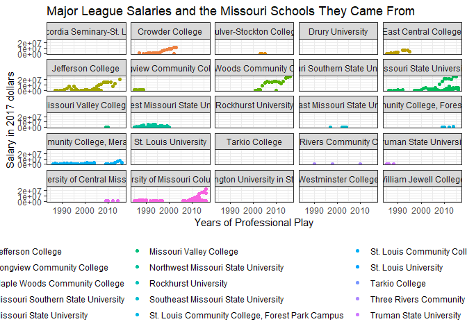

```r
p <- ggplot(data = playersinsalaryorder, mapping = aes(x = salyr,
                                       y = sal2017,
                                       color = name_full)) +
  geom_point() +
  labs(x = "Years of Professional Play",
       y = "Salary in 2017 dollars",
       title = "Major League Salaries and the Missouri Schools They Came From",
       color = "School") +
  theme(plot.title = element_text(hjust = .5)) +
  theme_bw() +
  facet_wrap(~ name_full, nrow = 5, ncol = 5) +
  theme(legend.position = "bottom")
p
```

```r
ggsave("BBPlot1.png", width = 15, height = 10, units = "in")  #saves to the project folder, overwrites without asking
# Plotting the Big4 and Adding an Average Line:  First, do you have the right packages loaded to computed averages? Then calculate the averages:
library(dplyr)
Big4Players <- filter(playersinsalaryorder, name_full == "Jefferson College" | name_full == "Maple Woods Community College" | name_full == "Missouri State University" | name_full == "University of Missouri Columbia")
Big4Players
```

```
##     nameFirst    nameLast     sal2017                          name salyr
## 1        Ryan      Howard 25773195.88         Philadelphia Phillies  2015
## 2        Ryan      Howard 25773195.88         Philadelphia Phillies  2015
## 3        Ryan      Howard 25773195.88         Philadelphia Phillies  2015
## 4        Ryan      Howard 25773195.88         Philadelphia Phillies  2014
## 5        Ryan      Howard 25773195.88         Philadelphia Phillies  2014
## 6        Ryan      Howard 25773195.88         Philadelphia Phillies  2014
## 7      Albert      Pujols 25510204.08 Los Angeles Angels of Anaheim  2016
## 8      Albert      Pujols 24742268.04 Los Angeles Angels of Anaheim  2015
## 9      Albert      Pujols 23711340.21 Los Angeles Angels of Anaheim  2014
## 10        Max    Scherzer 22594752.04          Washington Nationals  2016
## 11        Max    Scherzer 22594752.04          Washington Nationals  2016
## 12        Max    Scherzer 22594752.04          Washington Nationals  2016
## 13       Ryan      Howard 21739130.43         Philadelphia Phillies  2011
## 14       Ryan      Howard 21739130.43         Philadelphia Phillies  2011
```

[output cut: 849 more lines]

```r
# pipe on page 5.13,  group_by and summarise on pg 5.11
averages <- Big4Players %>%    #pg 5.13
  group_by(name_full) %>%
  summarise(avgsal = mean(sal2017, na.rm = TRUE))
averages
```

```
## # A tibble: 4 x 2
##   name_full                          avgsal
##   <chr>                               <dbl>
## 1 Jefferson College                4640713.
## 2 Maple Woods Community College   13281644.
## 3 Missouri State University        4956607.
## 4 University of Missouri Columbia  3121782.
```

### This plot shows the number of occurrences when a school produced a player, playing in a particular season. The horizontal line shows the average for all players from that school.

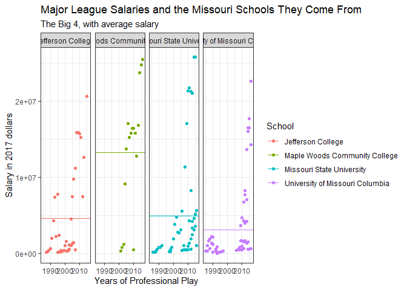

```r
ggplot(data = Big4Players, mapping = aes(x = salyr,
                                              y = sal2017,
                                              color = name_full)) +
  geom_point() +
  labs(x = "Years of Professional Play",
       y = "Salary in 2017 dollars",
       title = "Major League Salaries and the Missouri Schools They Come From",
       subtitle = "The Big 4, with average salary",
              color = "School") +
  theme(plot.title = element_text(hjust = .5)) +
  theme_bw() +
  facet_wrap(~ name_full, nrow = 1) +
  geom_hline(data = averages, mapping = aes( yintercept = avgsal, color = name_full))   #pg3.8
```

```r
ggsave("BBPlot2.png", width = 8, units = "in")
```

### This plot zooms in on the top dollar bracket, to see which school produced the highest paid player.

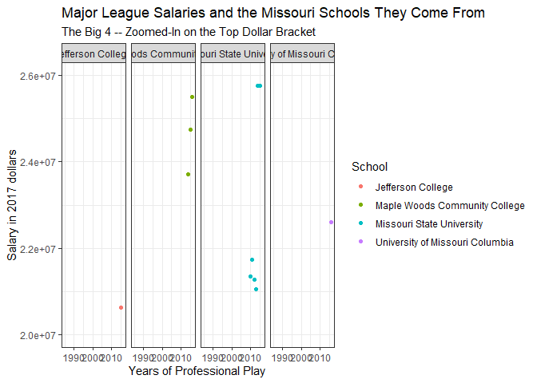

```r
ggplot(data = Big4Players, mapping = aes(x = salyr,
                                         y = sal2017,
                                         color = name_full)) +
  geom_point() +
  labs(x = "Years of Professional Play",
       y = "Salary in 2017 dollars",
       title = "Major League Salaries and the Missouri Schools They Come From",
       subtitle = "The Big 4 -- Zoomed-In on the Top Dollar Bracket",
       color = "School") +
  theme(plot.title = element_text(hjust = .5)) +
  theme_bw() +
  facet_wrap(~ name_full, nrow = 1) +
  coord_cartesian(ylim = c(20000000, 26000000))
```

```r
ggsave("BBPlot3.png", width = 8, units = "in")
```

### In summary, **Missouri State University** barely edges out Maple Woods Community College for the **highest paid individual** player. But **Maple Woods Community College** takes the honors for the **highest average** salary. And **University of Missouri Columbia** barely takes the prize for producing the **most players** who have contributed to the game.

[ ] Create a report in an .Rmd file with your code hidden but with reproducible data that explains your conclusions and includes your graphic. Save your .Rmd, .md, .html and .R script and image to your repository. ### Notes on Chap 13